# Investigating the settings of identity

Ting-Hsuan Chen

29 October, 2026

Tables and images saved in  
/workspace/cflthc/script/TEgenomeSimulator_publication_code/output/tair10_sd_scenarios/

## 1. Load files

## 2 Mean ± SD across 5 replicates, coloured by scenario (replaces Fig 3E)

Bin mean/SD are extracted via `ggplot_build()` from per-replicate histograms built purely for that purpose (not displayed) - same approach as `item29_Simulator_comparison_raw.Rmd`’s divergence mean/SD line graph, so the line graph’s bins always match what a histogram of the same data would show.

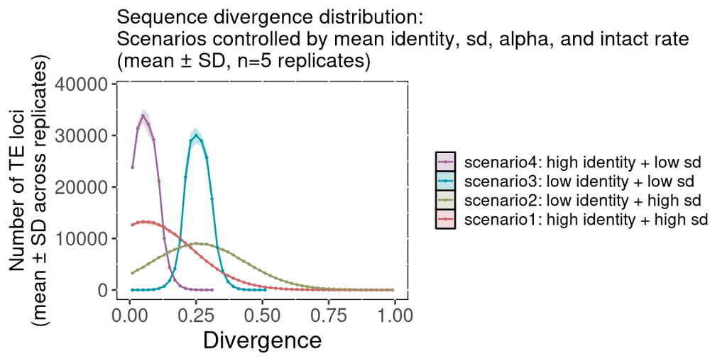

## 3. Test RepeatMasker recovery rate (5 replicates per scenario)

Heatmap cells show the mean of the replicate recovery rates; a replicate with no simulated TE in a cell is skipped, and cells empty in all 5 replicates are grey. Numbers in the cells are the mean number of simulated TEs per replicate (k = thousands). Marginal bars show the pooled rate of each slice, sum(recovered) / sum(total), computed within each replicate and then summarised as mean ± SD across the 5 replicates.

### 3.1 Recovery rate heatmaps (Fig 5B)

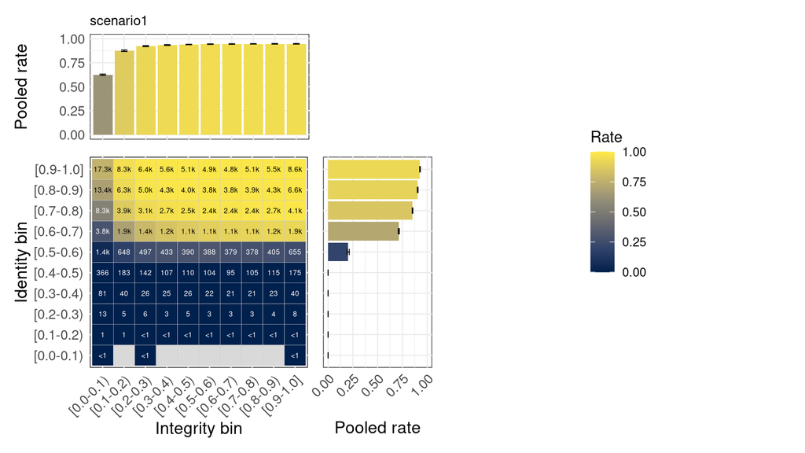

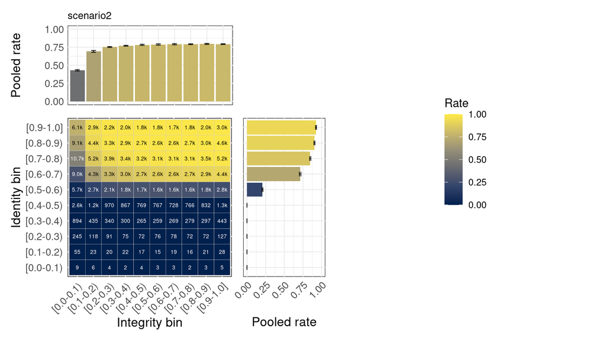

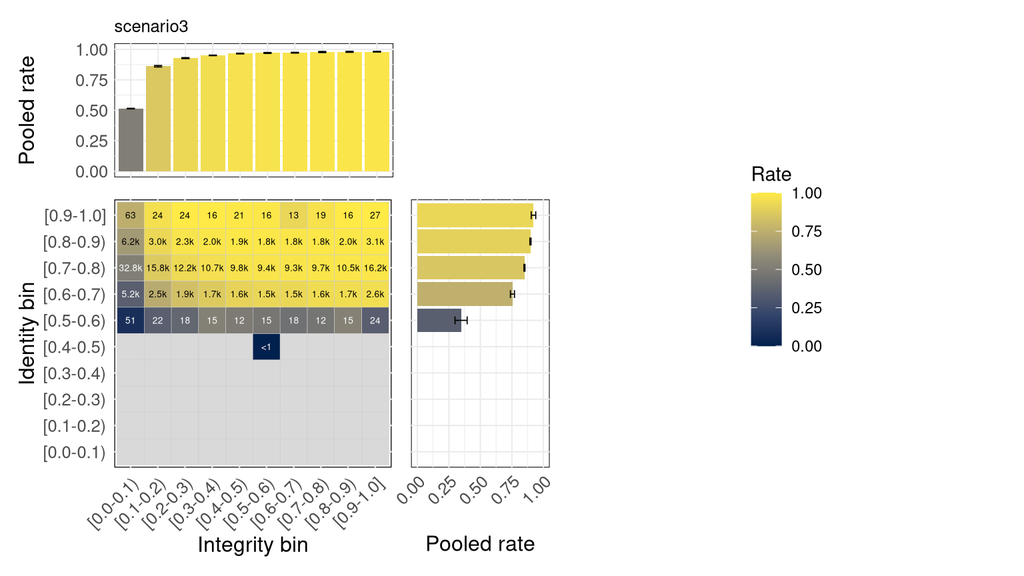

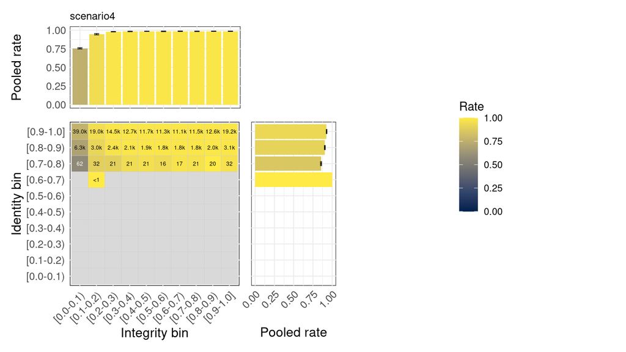

### 3.2 Between-replicate variability per cell (supplementary)

Fill is the SD of the recovery rate across replicates. Numbers mark cells where fewer than 5 replicates contain any simulated TE (value = number of replicates); light blue cells hold TEs in only one replicate, so no SD can be computed.

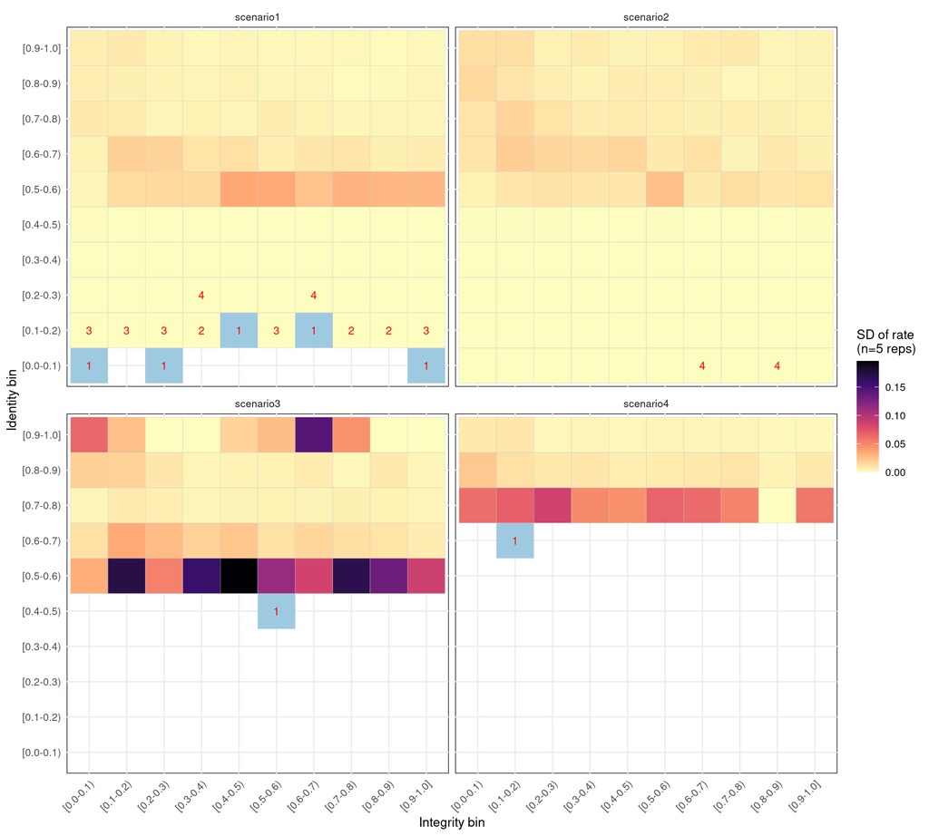

### 3.3 Overall recovery per scenario (mean ± SD across replicates)

| scenario | n_reps | total_mean | total_sd | rate_mean | rate_sd |
| --- | --- | --- | --- | --- | --- |
| scenario1 | 5 | 184517.4 | 5861.782 | 0.8571 | 0.0033 |
| scenario2 | 5 | 184671.8 | 3030.882 | 0.6881 | 0.0069 |
| scenario3 | 5 | 184611.0 | 5526.680 | 0.8448 | 0.0025 |
| scenario4 | 5 | 189079.4 | 4566.480 | 0.9243 | 0.0039 |

### 3.4 Binomial GLMM: identity vs integrity dependence

Recovery rises steeply with identity (≈0 below 0.5, ≈0.95 above 0.75), while integrity only matters in the lowest bin (< 0.1), where recovery plateaus at ≈0.70-0.77 even at identity 0.95. The main model is built to follow that shape, per scenario:

`cbind(recovered, total - recovered) ~ ns(identity, df = 3) * integrity_low + (1 | rep) + (1 | obs)`

- `ns(identity, df = 3)`: natural cubic spline of the identity bin midpoint (allows the threshold). df is capped at (number of identity bins - 2) so the spline cannot pass through every point and oscillate between them; scenario 4 has only 4 identity bins and gets df = 2.
- `integrity_low`: integrity bin `[0.0-0.1)` vs the rest (`>=0.1`, the reference level).
- `(1 | obs)`: observation-level random effect per cell × replicate, absorbing the extra-binomial variation between cells (the dispersion ratio, Pearson χ² / residual df, should be ≤ 1).
- `rep_sd` near 0 (singular fit) means the replicates do not differ beyond sampling noise.

Likelihood-ratio tests (LRT) drop all terms involving one variable (main effect + interaction). With ~180,000 TEs per replicate almost any term is significant, so compare the size of the LRT statistics rather than p-values. The two linear models (identity and integrity as bin midpoints, centred at 0.5 and scaled so one unit is one bin; odds ratios per 0.1 increase) are kept for reference: they cannot follow the identity threshold or the low-integrity plateau, so their integrity statistics understate the effect of the lowest integrity bin.

LRT for identity terms and integrity terms (each dropping main effect + interaction)

| scenario | model | n_cells | rep_sd | singular | dispersion | identity_chisq | identity_df | identity_p | integrity_chisq | integrity_df | integrity_p |
| --- | --- | --- | --- | --- | --- | --- | --- | --- | --- | --- | --- |
| scenario1 | ns(identity, df = 3) * integrity_low + (1 \| rep) + (1 \| obs) | 424 | 0.0000 | TRUE | 0.0328 | 1474.3092 | 6 | 0 | 361.0159 | 4 | 0 |
| scenario2 | ns(identity, df = 3) * integrity_low + (1 \| rep) + (1 \| obs) | 498 | 0.1143 | FALSE | 0.0870 | 1675.7118 | 6 | 0 | 338.6683 | 4 | 0 |
| scenario3 | ns(identity, df = 3) * integrity_low + (1 \| rep) + (1 \| obs) | 251 | 0.0000 | TRUE | 0.2795 | 440.3257 | 6 | 0 | 250.7877 | 4 | 0 |
| scenario4 | ns(identity, df = 2) * integrity_low + (1 \| rep) + (1 \| obs) | 151 | 0.1020 | FALSE | 0.2964 | 31.1939 | 4 | 0 | 158.7189 | 3 | 0 |
| scenario1 | identity * integrity + (1 \| rep) + (1 \| obs) | 424 | 0.0000 | TRUE | 0.0860 | 753.7755 | 2 | 0 | 48.4204 | 2 | 0 |
| scenario2 | identity * integrity + (1 \| rep) + (1 \| obs) | 498 | 0.0000 | TRUE | 0.0536 | 873.0037 | 2 | 0 | 31.4603 | 2 | 0 |
| scenario3 | identity * integrity + (1 \| rep) + (1 \| obs) | 251 | 0.0000 | TRUE | 0.5525 | 317.3777 | 2 | 0 | 161.2042 | 2 | 0 |
| scenario4 | identity * integrity + (1 \| rep) + (1 \| obs) | 151 | 0.0983 | FALSE | 0.2286 | 20.6005 | 2 | 0 | 102.3347 | 2 | 0 |
| scenario1 | identity * integrity + (1 \| rep) | 424 | 0.0286 | FALSE | 501.5103 | 148495.7394 | 2 | 0 | 124844.3168 | 2 | 0 |
| scenario2 | identity * integrity + (1 \| rep) | 498 | 0.0586 | FALSE | 7664.8210 | 477025.9443 | 2 | 0 | 160003.4478 | 2 | 0 |
| scenario3 | identity * integrity + (1 \| rep) | 251 | 0.0208 | FALSE | 312.4551 | 15431.5536 | 2 | 0 | 202054.8179 | 2 | 0 |
| scenario4 | identity * integrity + (1 \| rep) | 151 | 0.0542 | FALSE | 206.7646 | 1091.9114 | 2 | 0 | 82040.2621 | 2 | 0 |

Fixed effects of the full models (linear models: odds ratio per 0.1 increase)

| scenario | model | term | estimate | se | odds_ratio | z | p |
| --- | --- | --- | --- | --- | --- | --- | --- |
| scenario1 | ns(identity, df = 3) * integrity_low + (1 \| rep) + (1 \| obs) | (Intercept) | -62.7235 | 5.2454 | 0.000000e+00 | -11.9578 | 0.0000 |
| scenario1 | ns(identity, df = 3) * integrity_low + (1 \| rep) + (1 \| obs) | ns(identity, df = 3)1 | 51.7095 | 3.7895 | 2.865074e+22 | 13.6454 | 0.0000 |
| scenario1 | ns(identity, df = 3) * integrity_low + (1 \| rep) + (1 \| obs) | ns(identity, df = 3)2 | 118.2641 | 10.0247 | 2.298482e+51 | 11.7973 | 0.0000 |
| scenario1 | ns(identity, df = 3) * integrity_low + (1 \| rep) + (1 \| obs) | ns(identity, df = 3)3 | 29.9670 | 1.8398 | 1.033956e+13 | 16.2878 | 0.0000 |
| scenario1 | ns(identity, df = 3) * integrity_low + (1 \| rep) + (1 \| obs) | integrity_low<0.1 | 16.1198 | 12.6806 | 1.001746e+07 | 1.2712 | 0.2037 |
| scenario1 | ns(identity, df = 3) * integrity_low + (1 \| rep) + (1 \| obs) | ns(identity, df = 3)1:integrity_low<0.1 | -15.5597 | 9.1041 | 0.000000e+00 | -1.7091 | 0.0874 |
| scenario1 | ns(identity, df = 3) * integrity_low + (1 \| rep) + (1 \| obs) | ns(identity, df = 3)2:integrity_low<0.1 | -33.9150 | 24.3188 | 0.000000e+00 | -1.3946 | 0.1631 |
| scenario1 | ns(identity, df = 3) * integrity_low + (1 \| rep) + (1 \| obs) | ns(identity, df = 3)3:integrity_low<0.1 | -8.4869 | 4.3986 | 2.000000e-04 | -1.9294 | 0.0537 |
| scenario2 | ns(identity, df = 3) * integrity_low + (1 \| rep) + (1 \| obs) | (Intercept) | -100.2464 | 0.0035 | 0.000000e+00 | -28563.9697 | 0.0000 |
| scenario2 | ns(identity, df = 3) * integrity_low + (1 \| rep) + (1 \| obs) | ns(identity, df = 3)1 | 78.0563 | 0.0035 | 7.932616e+33 | 22221.0503 | 0.0000 |
| scenario2 | ns(identity, df = 3) * integrity_low + (1 \| rep) + (1 \| obs) | ns(identity, df = 3)2 | 182.4213 | 0.0035 | 1.677047e+79 | 51904.6435 | 0.0000 |
| scenario2 | ns(identity, df = 3) * integrity_low + (1 \| rep) + (1 \| obs) | ns(identity, df = 3)3 | 52.2267 | 0.0035 | 4.805838e+22 | 14861.7757 | 0.0000 |
| scenario2 | ns(identity, df = 3) * integrity_low + (1 \| rep) + (1 \| obs) | integrity_low<0.1 | 25.5471 | 0.0035 | 1.244436e+11 | 7270.3072 | 0.0000 |
| scenario2 | ns(identity, df = 3) * integrity_low + (1 \| rep) + (1 \| obs) | ns(identity, df = 3)1:integrity_low<0.1 | -22.5146 | 0.0036 | 0.000000e+00 | -6203.7181 | 0.0000 |
| scenario2 | ns(identity, df = 3) * integrity_low + (1 \| rep) + (1 \| obs) | ns(identity, df = 3)2:integrity_low<0.1 | -49.5910 | 0.0036 | 0.000000e+00 | -13660.9585 | 0.0000 |
| scenario2 | ns(identity, df = 3) * integrity_low + (1 \| rep) + (1 \| obs) | ns(identity, df = 3)3:integrity_low<0.1 | -14.6347 | 0.0036 | 0.000000e+00 | -4031.6658 | 0.0000 |
| scenario3 | ns(identity, df = 3) * integrity_low + (1 \| rep) + (1 \| obs) | (Intercept) | -3.4234 | 0.3519 | 3.260000e-02 | -9.7286 | 0.0000 |
| scenario3 | ns(identity, df = 3) * integrity_low + (1 \| rep) + (1 \| obs) | ns(identity, df = 3)1 | 6.0212 | 0.2431 | 4.120725e+02 | 24.7705 | 0.0000 |
| scenario3 | ns(identity, df = 3) * integrity_low + (1 \| rep) + (1 \| obs) | ns(identity, df = 3)2 | 13.1716 | 0.8558 | 5.252526e+05 | 15.3918 | 0.0000 |
| scenario3 | ns(identity, df = 3) * integrity_low + (1 \| rep) + (1 \| obs) | ns(identity, df = 3)3 | 3.7536 | 0.2690 | 4.267650e+01 | 13.9562 | 0.0000 |
| scenario3 | ns(identity, df = 3) * integrity_low + (1 \| rep) + (1 \| obs) | integrity_low<0.1 | -1.3154 | 1.0802 | 2.684000e-01 | -1.2178 | 0.2233 |
| scenario3 | ns(identity, df = 3) * integrity_low + (1 \| rep) + (1 \| obs) | ns(identity, df = 3)1:integrity_low<0.1 | -1.9767 | 0.7325 | 1.385000e-01 | -2.6985 | 0.0070 |
| scenario3 | ns(identity, df = 3) * integrity_low + (1 \| rep) + (1 \| obs) | ns(identity, df = 3)2:integrity_low<0.1 | -3.5384 | 2.4365 | 2.910000e-02 | -1.4523 | 0.1464 |
| scenario3 | ns(identity, df = 3) * integrity_low + (1 \| rep) + (1 \| obs) | ns(identity, df = 3)3:integrity_low<0.1 | -0.8618 | 0.4722 | 4.224000e-01 | -1.8250 | 0.0680 |
| scenario4 | ns(identity, df = 2) * integrity_low + (1 \| rep) + (1 \| obs) | (Intercept) | 1.4324 | 0.0025 | 4.188600e+00 | 567.2014 | 0.0000 |
| scenario4 | ns(identity, df = 2) * integrity_low + (1 \| rep) + (1 \| obs) | ns(identity, df = 2)1 | 4.5415 | 0.0025 | 9.383320e+01 | 1798.4723 | 0.0000 |
| scenario4 | ns(identity, df = 2) * integrity_low + (1 \| rep) + (1 \| obs) | ns(identity, df = 2)2 | 1.1022 | 0.0025 | 3.010700e+00 | 436.4028 | 0.0000 |
| scenario4 | ns(identity, df = 2) * integrity_low + (1 \| rep) + (1 \| obs) | integrity_low<0.1 | -1.5790 | 0.0025 | 2.062000e-01 | -625.4282 | 0.0000 |
| scenario4 | ns(identity, df = 2) * integrity_low + (1 \| rep) + (1 \| obs) | ns(identity, df = 2)1:integrity_low<0.1 | -2.7594 | 0.0025 | 6.330000e-02 | -1092.9208 | 0.0000 |
| scenario4 | ns(identity, df = 2) * integrity_low + (1 \| rep) + (1 \| obs) | ns(identity, df = 2)2:integrity_low<0.1 | -0.1927 | 0.0026 | 8.248000e-01 | -73.8958 | 0.0000 |
| scenario1 | identity * integrity + (1 \| rep) + (1 \| obs) | (Intercept) | -2.9545 | 0.1520 | 5.210000e-02 | -19.4434 | 0.0000 |
| scenario1 | identity * integrity + (1 \| rep) + (1 \| obs) | identity | 1.8768 | 0.0554 | 6.532600e+00 | 33.9069 | 0.0000 |
| scenario1 | identity * integrity + (1 \| rep) + (1 \| obs) | integrity | 0.1517 | 0.0469 | 1.163800e+00 | 3.2319 | 0.0012 |
| scenario1 | identity * integrity + (1 \| rep) + (1 \| obs) | identity:integrity | 0.0360 | 0.0176 | 1.036600e+00 | 2.0488 | 0.0405 |
| scenario2 | identity * integrity + (1 \| rep) + (1 \| obs) | (Intercept) | -4.1573 | 0.1752 | 1.560000e-02 | -23.7270 | 0.0000 |
| scenario2 | identity * integrity + (1 \| rep) + (1 \| obs) | identity | 2.2813 | 0.0653 | 9.789800e+00 | 34.9607 | 0.0000 |
| scenario2 | identity * integrity + (1 \| rep) + (1 \| obs) | integrity | 0.0989 | 0.0545 | 1.103900e+00 | 1.8123 | 0.0699 |
| scenario2 | identity * integrity + (1 \| rep) + (1 \| obs) | identity:integrity | 0.0583 | 0.0208 | 1.060000e+00 | 2.7959 | 0.0052 |
| scenario3 | identity * integrity + (1 \| rep) + (1 \| obs) | (Intercept) | -0.3839 | 0.1336 | 6.812000e-01 | -2.8738 | 0.0041 |
| scenario3 | identity * integrity + (1 \| rep) + (1 \| obs) | identity | 1.2399 | 0.0539 | 3.455400e+00 | 23.0002 | 0.0000 |
| scenario3 | identity * integrity + (1 \| rep) + (1 \| obs) | integrity | 0.1354 | 0.0450 | 1.145000e+00 | 3.0100 | 0.0026 |
| scenario3 | identity * integrity + (1 \| rep) + (1 \| obs) | identity:integrity | 0.0867 | 0.0177 | 1.090600e+00 | 4.8928 | 0.0000 |
| scenario4 | identity * integrity + (1 \| rep) + (1 \| obs) | (Intercept) | 2.4150 | 0.4029 | 1.118920e+01 | 5.9940 | 0.0000 |
| scenario4 | identity * integrity + (1 \| rep) + (1 \| obs) | identity | 0.3031 | 0.1035 | 1.354100e+00 | 2.9298 | 0.0034 |
| scenario4 | identity * integrity + (1 \| rep) + (1 \| obs) | integrity | 0.6593 | 0.1317 | 1.933500e+00 | 5.0064 | 0.0000 |
| scenario4 | identity * integrity + (1 \| rep) + (1 \| obs) | identity:integrity | -0.0984 | 0.0343 | 9.063000e-01 | -2.8687 | 0.0041 |
| scenario1 | identity * integrity + (1 \| rep) | (Intercept) | -1.1647 | 0.0168 | 3.120000e-01 | -69.1379 | 0.0000 |
| scenario1 | identity * integrity + (1 \| rep) | identity | 1.4868 | 0.0056 | 4.423000e+00 | 266.5055 | 0.0000 |
| scenario1 | identity * integrity + (1 \| rep) | integrity | 0.0064 | 0.0030 | 1.006500e+00 | 2.1318 | 0.0330 |
| scenario1 | identity * integrity + (1 \| rep) | identity:integrity | 0.1949 | 0.0014 | 1.215200e+00 | 139.0964 | 0.0000 |
| scenario2 | identity * integrity + (1 \| rep) | (Intercept) | -2.1211 | 0.0273 | 1.199000e-01 | -77.7105 | 0.0000 |
| scenario2 | identity * integrity + (1 \| rep) | identity | 2.2054 | 0.0062 | 9.073700e+00 | 356.9281 | 0.0000 |
| scenario2 | identity * integrity + (1 \| rep) | integrity | -0.0722 | 0.0021 | 9.304000e-01 | -34.8652 | 0.0000 |
| scenario2 | identity * integrity + (1 \| rep) | identity:integrity | 0.3130 | 0.0015 | 1.367600e+00 | 207.1122 | 0.0000 |
| scenario3 | identity * integrity + (1 \| rep) | (Intercept) | -0.1275 | 0.0333 | 8.803000e-01 | -3.8269 | 0.0001 |
| scenario3 | identity * integrity + (1 \| rep) | identity | 1.4603 | 0.0145 | 4.307100e+00 | 100.8382 | 0.0000 |
| scenario3 | identity * integrity + (1 \| rep) | integrity | 0.1551 | 0.0085 | 1.167800e+00 | 18.3212 | 0.0000 |
| scenario3 | identity * integrity + (1 \| rep) | identity:integrity | 0.2176 | 0.0037 | 1.243100e+00 | 58.0265 | 0.0000 |
| scenario4 | identity * integrity + (1 \| rep) | (Intercept) | 3.6441 | 0.1284 | 3.824730e+01 | 28.3896 | 0.0000 |
| scenario4 | identity * integrity + (1 \| rep) | identity | 0.0365 | 0.0288 | 1.037100e+00 | 1.2651 | 0.2058 |
| scenario4 | identity * integrity + (1 \| rep) | integrity | 0.8894 | 0.0323 | 2.433700e+00 | 27.5475 | 0.0000 |
| scenario4 | identity * integrity + (1 \| rep) | identity:integrity | -0.0839 | 0.0074 | 9.196000e-01 | -11.3548 | 0.0000 |

**A**: LRT χ² of the main model for dropping the identity terms vs the integrity terms. **B**: recovery rate against identity. Large points with error bars are pooled rates, sum(recovered) / sum(total), for integrity < 0.1 and ≥ 0.1 (mean ± SD of the 5 replicates); small light points are the 9 individual integrity bins ≥ 0.1 (mean of replicate rates), showing that they behave alike. Lines are the main GLMM’s fixed-effect predictions (random effects at 0, i.e. a typical cell).

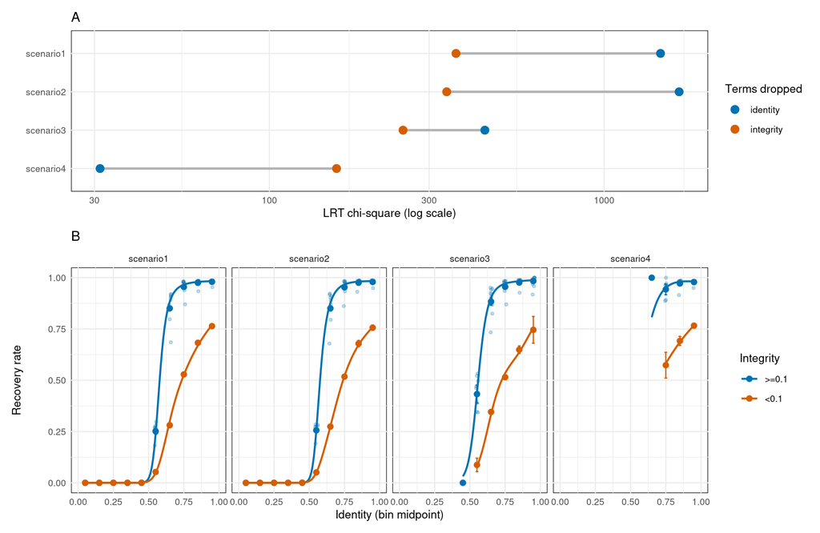